# Arrange links evenly along the sectors

Zuguang Gu

2020-11-23

People use `circos.link()` to visualize interactions/relations between sectors. When one sector has more than one other sectors to interact with, it actually becomes important of how to arrange links on that sector to make every link readable.

In the following example, I created a random interaction data frame `df`:

```r
set.seed(123)
sectors = letters[1:20]
df = data.frame(from = sample(sectors, 40, replace = TRUE),
                to   = sample(sectors, 40, replace = TRUE))
df = unique(df)
df = df[df$from != df$to, ]
df
```

```
##    from to
## 1     o  a
## 2     s  f
## 3     n  o
## 4     c  i
## 5     j  o
## 6     r  p
## 7     k  t
## 8     e  f
## 9     t  k
## 10    n  h
## 11    e  g
## 12    s  p
## 13    i  q
## 14    c  r
```

[output cut: 25 more lines]

I also created the corresponding circular plot with all the sectors. In the simplest way, we might want to put all the links to the center of every sector, which looks like follows:

```r
library(circlize)
circos.initialize(sectors, xlim = c(0, 1))
circos.track(ylim = c(0, 1), panel.fun = function(x, y) {
    circos.text(CELL_META$xcenter, CELL_META$ycenter, CELL_META$sector.index)
})
for(i in seq_len(nrow(df))) {
    s1 = df[i, 1]
    s2 = df[i ,2]
    circos.link(s1, 0.5, s2, 0.5, directional = 1)
}
```

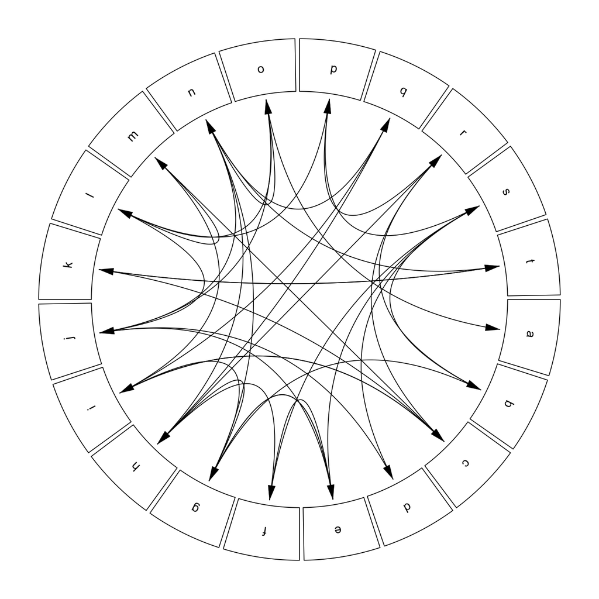

It looks nice, but since all the links, *e.g.* which start from or end in one sector, are in a same position, it is rather difficult to tell which sector has more links than the others.

To get rid of such link overlapping, we can assign random shift to every link in the sector. In the following example, since the `xlim` for all sectors are fixed in `c(0, 1)`, we use `runif(1)` to assign a random position between 0 and 1.

```r
circos.initialize(sectors, xlim = c(0, 1))
circos.track(ylim = c(0, 1), panel.fun = function(x, y) {
    circos.text(CELL_META$xcenter, CELL_META$ycenter, CELL_META$sector.index)
})
for(i in seq_len(nrow(df))) {
    s1 = df[i, 1]
    s2 = df[i ,2]
    circos.link(s1, runif(1), s2, runif(1), directional = 1)
}
```

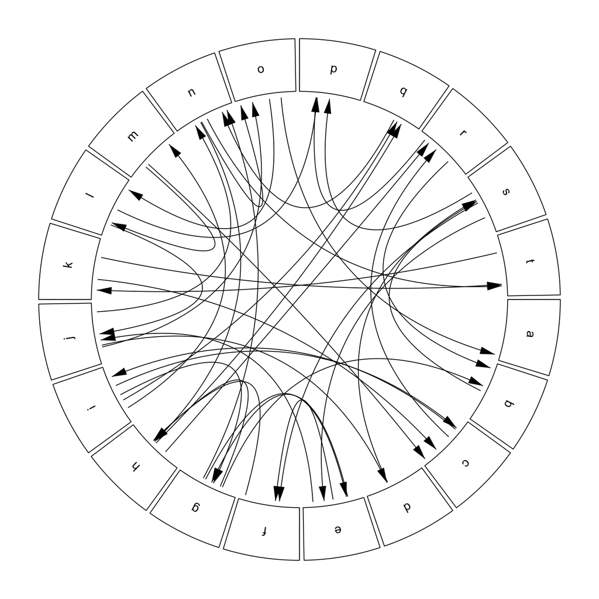

It already looks much nicer, however, since the positions are random, it is still not easy to tell which sector has more links because we need effort to carefully count the links if they are very close to each other (*e.g.*, for sector c, are there four or five links?).

From **circlize** version 0.4.12.1001, I added a new function `arrange_links_evenly()` which can arrange the links on the sectors so that the neighouring distance between links are evenly distributed. It also adjusts positions of links to make the overall intersection of linkes minimal. Additionally, it considers directional links, *i.e.*, on each sector, the starting links and the ending links are put into separate groups.

```r
circos.initialize(sectors, xlim = c(0, 1))
circos.track(ylim = c(0, 1), panel.fun = function(x, y) {
    circos.text(CELL_META$xcenter, CELL_META$ycenter, CELL_META$sector.index)
})

df2 = arrange_links_evenly(df, directional = 1)

for(i in seq_len(nrow(df2))) {
    s1 = df$from[i]
    s2 = df$to[i]
    circos.link(df2[i, "sector1"], df2[i, "pos1"],
                df2[i, "sector2"], df2[i, "pos2"],
                directional = 1)
}
```

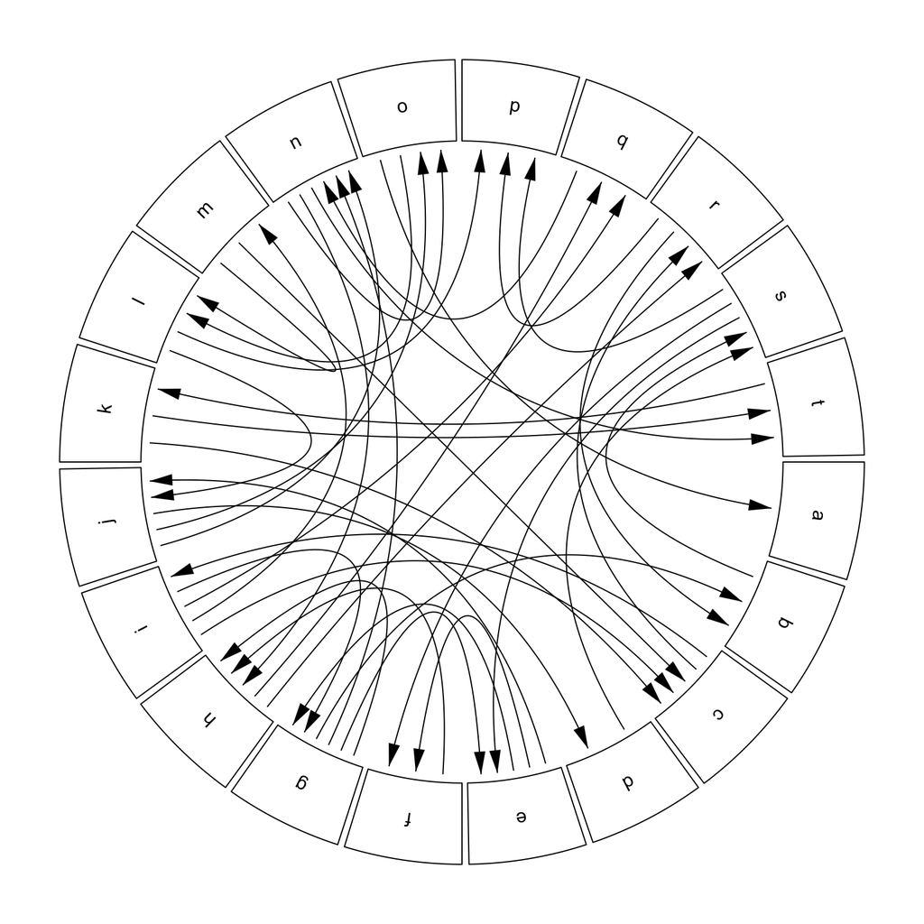